# Data Skills

Team Profound Specialists  
10/28/2018

**Question:** Which skills are required to be a data scientist?

**Team Members:** simplymathematics, jemceach, ritwar01, ghh2001, & johnpannyc

### Overview

- Sources
- Roles
- Tools
- Skills
- Characteristics
- Salary
- Outlook
- Technical skills
- Indeed
- Conclusion

### Sources

- U.S. Bureau of Labor Statistics:
  - [Occupational Employment Statistics (OES)](https://www.bls.gov/oes/current/oes150000.htm#nat)
  - [Occupational Projections (EP)](https://data.bls.gov/projections/occupationProj)
- [Occupational Information Network (O*NET)](https://www.onetonline.org/):
  - Soft Skills
  - Technology and Tools
- Indeed

### Roles

- **Characteristics:** @simplymathmatics & @jemceach
- **Salary:** @simplymathmatics & @jemceach
- **Skills:** @simplymathmatics & @jemceach
- **Technical Skills:** @simplymathematics & @jemceach
- **Indeed Skills:** @ritwar01
- **SQL:** @simplymathematics
- **Write up and analysis:** @simplymathematics & @jemceach
- **Presentation:** @ritwar01, @simplymathematics, @jemceach

### Tools

**Communication:**

- Email
- Slack

**Production**

- Github
- RStudio
- Rpres

*Github Issues Tool*

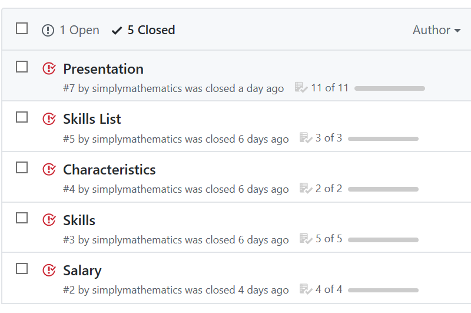

### Skills

- Scraped and cleaned data from O*NET
- Evaluted data on scale of importance (0-7).
- Findings: Top 5 Skills for Math and Computer Science Jobs:

| Element | avgvalue | n |
| --- | --- | --- |
| Critical Thinking | 3.936667 | 16 |
| Complex Problem Solving | 3.714286 | 16 |
| Reading Comprehension | 3.660000 | 16 |
| Judgment and Decision Making | 3.638889 | 16 |
| Active Listening | 3.605000 | 16 |

### Characteristics

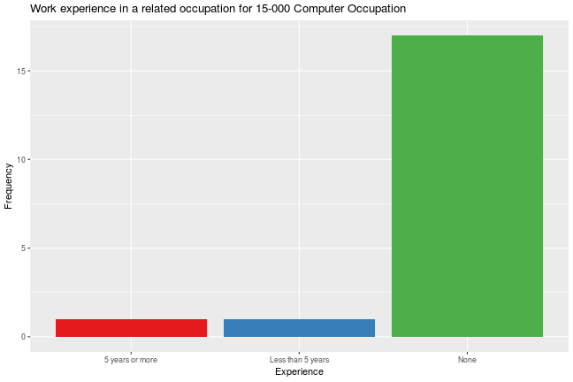

### Characteristics (Cont.)

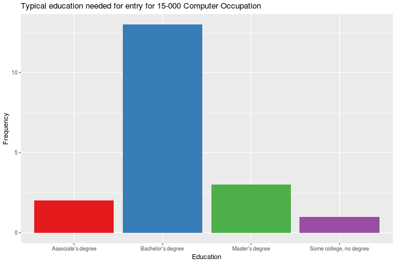

### Salary

Scraped Salary Data from BLS

| SOC | Title | Mean.Annual.Wage |
| --- | --- | --- |
| 1133 | Software developers, systems software | 111780 |
| 1134 | Web developers | 74110 |
| 1141 | Database administrators | 89050 |
| 1142 | Network and computer systems administrators | 86340 |
| 1143 | Computer network architects | 107870 |
| 1151 | Computer user support specialists | 54150 |
| 1152 | Computer network support specialists | 67510 |

### Salary (cont.)

Scraped Salary Data from BLS

| SOC | Title | Mean.Annual.Wage |
| --- | --- | --- |
| 1199 | Computer occupations, all other | 91080 |
| 2011 | Actuaries | 114850 |
| 2021 | Mathematicians | 104700 |
| 2031 | Operations research analysts | 86510 |
| 2041 | Statisticians | 88980 |
| 2090 | Miscellaneous mathematical science occupations | 73670 |

### Evaluation of Annual Wage Data

Mean

```
[1] 88507.69
```

Standard Deviation:

```
[1] 18113.61
```

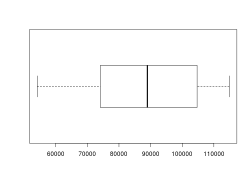

### Outlook Analysis

- Significant deviation in pay amongst occupations.
- Considerable room for advancement!

| Title | 2016Wage | 2016-26.EmplChange |
| --- | --- | --- |
| Statisticians | 88980 | 33.8 |
| Mathematicians | 104700 | 29.7 |
| Operations research analysts | 86510 | 27.4 |
| Actuaries | 114850 | 22.5 |

### Salary vs. Outlook (cont.)

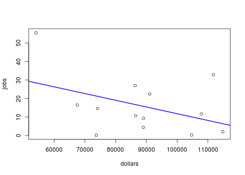

### Technical Skills

- Scraped and cleaned data from O*NET
- Evaluted the frequency technical skills.
- Findings: Top 5 technical skills for mathematical and computational occupations:

| Commodity.Title | n |
| --- | --- |
| Development environment software | 437 |
| Web platform development software | 371 |
| Object or component oriented development software | 303 |
| Data base management system software | 289 |
| Analytical or scientific software | 248 |

### BLS/ONET Findings

- Developed a broad picture of the computational and mathematical field.
- Unable draw any conlusions further statistical analysis about:
  - Which skills are in growing fields
  - Salary variations within skillsets

#### We next consulted Indeed next to compare the DOL datasets

#### to current job postings in the NY/CA area.

### Indeed (CA)

- Webscrape indeed CA for specific data scientist skill sets
- [Scraped](http://rpubs.com/ritwar01/D607Project3v1) and cleaned data from Indeed.
- Total the count of each skill set.
- Findings: Top 5 CA Data Scientist Skill sets listed on indeed.

| Keyword | n |
| --- | --- |
| Machine Learning | 173 |
| SQL | 146 |
| Python | 142 |
| AI | 115 |
| AWS | 75 |

### Indeed (NY)

**Indeed.com**

- [Scraped](http://rpubs.com/ritwar01/D607Project3v1) and cleaned data from Indeed.
- Total the count of each skill set.
- Findings: Top 5 NY Data Scientist Skill sets listed on indeed:

| Keyword | n |
| --- | --- |
| Python | 54 |
| SQL | 45 |
| Hadoop | 41 |
| AI | 33 |
| Machine Learning | 26 |

### Indeed State Comparisons

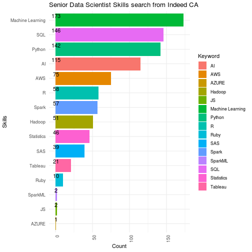

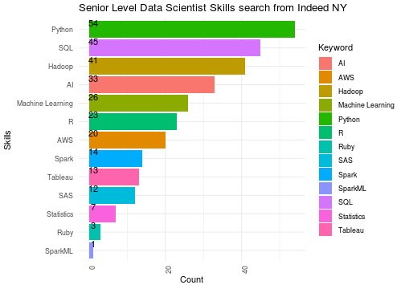

### Data Comparisons

- Specific technical skills required for “Data Scientists.”
- Unable to make direct comparison to ONET/BLS data.
- We were still able to draw parallels between the datasets:

| ONET/BLS Data | Indeed Equivalence |
| --- | --- |
| Development environment software | Python, Hadoop, AWS, Spark |
| Web platform development software | Ruby, PHP, JS |
| Object or component oriented development software | R, AI, SAS, Spark, ML |
| Data base management system software | SQL, Tableau |
| Analytical or scientific software | R, Spark, Tableau, SAS, Statistics |

### Conclusion (cont.)

Data Challenges

- BLS and ONET databases are very broad and do little to highlight specific requirements
- Project required further rurther regression analysis to map skills with occupational growth/salary
- Time constraints with scraping data from Indeed.

Group Challenges

- Steep learning curve associated with git
- Version control
- Coordination and management of work

### SQL Database

- SQL database stored in github repository: “csvs/db.sqlite”
- Loaded csv files into corresponding tables
- Further documentation stored in “csvs/SQL.Rmd”

### Further Research

- ANOVA test that maps skills to pay
- Redo analysis with new SOC data that includes a specific 'data science' category
- Include other job websites in our scraping and weight the results from each.